# Phase 1 Quick Reference

## Disciplined Processes

### Overall ES103 Disciplined Process

The following approach can be used for building any model of a system.

1. Scope your system model.
2. Construct your model.
3. Evaluate your model.

The most mathematically involved part of this process is often model construction. We have developed two disciplined processes for model construction in the course so far.

### Model Construction using Newton's Laws

1. Draw the FBD for each individual element in the system
2. Write Newton's second law for each individual element in the system, using sums of forces and/or torques as appropriate given the motion of your system
3. Eliminate all motion and force terms other than terms multiplied by the system's dependent variables (and their derivatives, as appropriate) using algebraic manipulation. Solving an equation for an unwanted term and substituting into another equation is a good way to eliminate the unwanted term.
4. Check to make sure that all terms multiplied by your model's dependent variables contain only known or measurable quantities (independent variables).

### Model Construction using Conservation of Energy (First Law of Thermodynamics)

If the system at hand is not purely mechanical, but it is a *physical* system, you can use conservation of energy to construct a system model. Constructing a model using the first law (FLT) can be achieved using the following disciplined process:

1. Draw an energetic diagram for each individual element in the system
2. Write the first law of thermodynamics for each individual element in the system.
3. Eliminate all terms other than those multiplied by the system's dependent variables (and their derivatives, as appropriate) using algebraic manipulation. Solving an equation for an unwanted term and substituting into another equation is a good way to eliminate the unwanted term.
4. Check to make sure that all terms multiplied by your model's dependent variables contain only known or measurable quantities (independent variables).

## Power Variables: A-Type and T-Type

In each of the cases above, the variables in the power equation can be grouped into categories based on how they are measured. these two categories are "across" and "through."

- **Across-type** (A-type) variables must be measured *relative to a reference*. Only differences in these quantities between two points can be measured. These variables are pressure $P$, velocity $v$, angular velocity $\Omega$, and voltage $V$.
- **Through-type** (T-type) variables must be measured by placing an instrument *in series* with a system element. Examples include current sensors, load cells, and flow rate gauges. The T-type variables in incompressible fluid, mechanical, and electrical systems are volumetric flow rate $\dot{\mathcal{V}}$, force $F$, torque $T$, and current $i$.

## Idealized Sources

It is sometimes safe to assume that the input to a dynamic, physical system is "ideal" in an energetic sense. Idealized sources provide *power* to the system, and can change its energetic sense.

### Assumptions

Idealized sources can provide a known input to a system, which is usually a power variable, **regardless of how much power is required** to maintain that known input. For example, if the input to a system is force, then we might say that an "idealized force source" is able to provide a *as much power as is required* to the system to maintain a known input force. These **infinite power** sources are not real, but many times are a good approximation for systems that operate in a relatively small range of energetic states.

Because power is the product of a T-type and an A-type variable, idealized sources are often classified as either "T-type" sources, which provide a known T-type input regardless of what A-type variable is required, or "A-type" sources, which provide a known A-type variable regardless of what T-type variable is required.

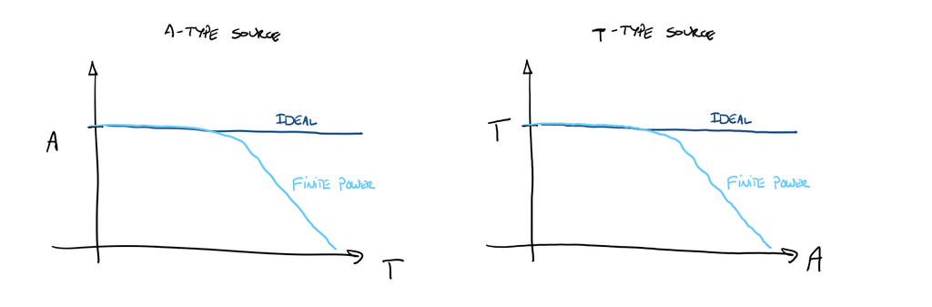

Note that in the figure, a line representing the possible behavior of a "real" power source, which only has a finite available power, is also included. Many real power sources can be approximated as ideal T-type or A-type sources if the power required by the system is low relative to the power source's capability.

### List of Common Idealized Power Sources

Common idealized T-type sources include:

- current sources in electrical systems
- force or torque sources in mechanical systems
- volumetric flow rate sources in fluid systems

Common idealized A-type sources include:

- voltage sources in electrical systems
- velocity or angular velocity sources in mechanical systems
- Pressure sources in fluid systems

## First Law Assumptions for Common System Elements

We often make similar assumptions about elements in physical systems. Below you'll find a chart that summarizes these assumptions for the elements we've considered so far in ES103. Note that these assumptions should still be **justified** in your work for your particular system and/or element.

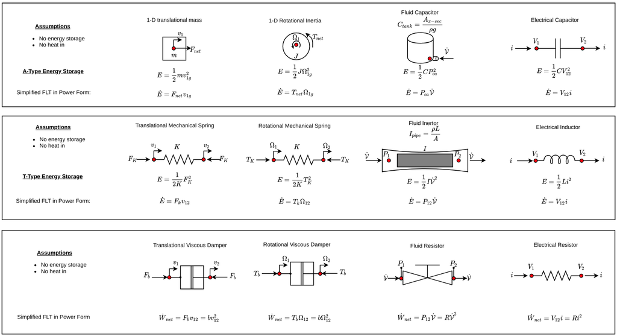

## Idealized Power-Converting Transducers

$$\dot{W}_{in} = \dot{W}_{out}$$

They convert power from one type to another without heat transfer to environment or energy storage. Link to Original Context in: Reading_16

A list of common power-converting transducers and their associated equations is shown below.

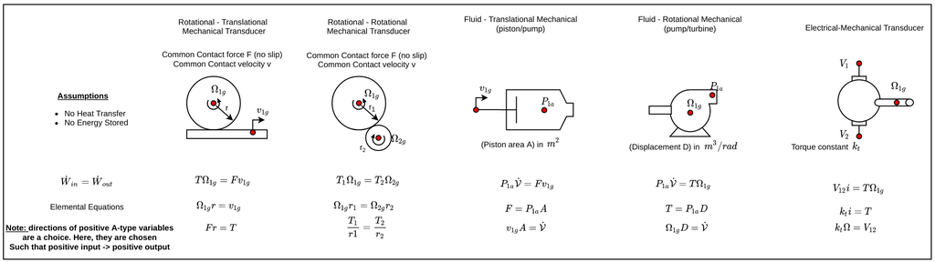